# Donor Profile: España con ACNUR

## Transaction Volatility

España con ACNUR’s funding profile shows a significant strategic gap compared to top donors, with an average transaction size of $639.3K through 181 annual transactions versus $2.9M across 587 transactions for benchmark peers. This smaller and less frequent funding pattern creates volatility that jeopardizes consistent resource flow vital for emergency response and resilience programming. The implication is a higher operational risk and reduced impact scale at critical moments. Targeted investment to increase transaction size and frequency could act as a powerful impact multiplier, stabilizing funding pipelines to maximize program reach. We recommend positioning this as a strategic priority in donor engagement, emphasizing the leverage potential for filling urgent gaps and scaling innovation. Immediate executive focus is required to diversify and deepen partnerships that can convert smaller, irregular funding into more predictable, larger commitments. Mobilizing resources now will safeguard operational continuity and accountability, directly aligning with donor priorities in crisis contexts.

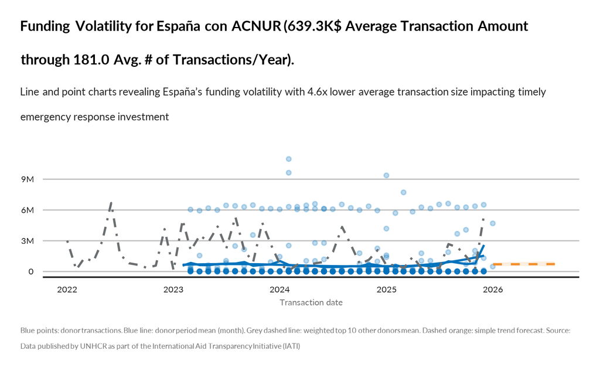

TRUE